# CUNY SPS DATA 621 - CTG5 - HW1

Betsy Rosalen, Gabrielle Bartomeo, Jeremy O’Brien, Lidiia Tronina, Rose Koh

February 27, 2019

# 1 DATA EXPLORATION

Professionals and gamblers alike are always seeking to optimize their chances of winning, whether it be sports, games, or their bets on them. Major League Baseball is a [multibillion dollar industry](https://www.forbes.com/sites/mikeozanian/2018/04/11/baseball-team-values-2018/#4675cfd43fc0) where individual teams, players, and those who profit off of their success stand to benefit most from such optimization.

Data from 1871 to 2006 was collected in order to infer how many wins could be expected from the 162 games in a baseball team’s season. Each observation represents a season for an unnamed team, and we have a total of 2,276 observations. For each team the target variable, `TARGET_WINS`, represents the number of wins in a given year and has a maximum value of 162 possible wins. In addition to that 15 continuous integer predictor variables were collected (not including the index) representing each team’s: base hits, doubles, triples, homeruns, walks, and strikeouts by batters, batters hit by pitches, bases stolen by batters and the number of times they were caught stealing, the number of errors, double plays, walks, hits, and homeruns allowed, and strikeouts by pitchers. The testing data contains the same 15 predictor variables and no target variable so it will be impossible to check the accuracy of our predictions from the testing data.

| VARIABLE NAME | DEFINITION | THEORETICAL EFFECT ON WINS |
| --- | --- | --- |
| TARGET_WINS | Number of wins | outcome variable |
| BATTING_H | Base Hits by batters (1B,2B,3B,HR) | Positive Impact |
| BATTING_2B | Doubles by batters (2B) | Positive Impact |
| BATTING_3B | Triples by batters (3B) | Positive Impact |
| BATTING_HR | Homeruns by batters (4B) | Positive Impact |
| BATTING_BB | Walks by batters | Positive Impact |
| BATTING_HBP | Batters hit by pitch (get a free base) | Positive Impact |
| BATTING_SO | Strikeouts by batters | Negative Impact |
| BASERUN_SB | Stolen bases | Positive Impact |
| BASERUN_CS | Caught stealing | Negative Impact |
| FIELDING_E | Errors | Negative Impact |
| FIELDING_DP | Double Plays | Positive Impact |
| PITCHING_BB | Walks allowed | Negative Impact |
| PITCHING_H | Hits allowed | Negative Impact |
| PITCHING_HR | Homeruns allowed | Negative Impact |
| PITCHING_SO | Strikeouts by pitchers | Positive Impact |

## 1.1 Summary Statistics

```
##                n  min    mean median   max      sd
## TARGET_WINS 2276    0   80.79   82.0   146   15.75
## BATTING_H   2276  891 1469.27 1454.0  2554  144.59
## BATTING_2B  2276   69  241.25  238.0   458   46.80
## BATTING_3B  2276    0   55.25   47.0   223   27.94
## BATTING_HR  2276    0   99.61  102.0   264   60.55
## BATTING_BB  2276    0  501.56  512.0   878  122.67
## BATTING_SO  2174    0  735.61  750.0  1399  248.53
## BASERUN_SB  2145    0  124.76  101.0   697   87.79
## BASERUN_CS  1504    0   52.80   49.0   201   22.96
## BATTING_HBP  191   29   59.36   58.0    95   12.97
## PITCHING_H  2276 1137 1779.21 1518.0 30132 1406.84
## PITCHING_HR 2276    0  105.70  107.0   343   61.30
## PITCHING_BB 2276    0  553.01  536.5  3645  166.36
## PITCHING_SO 2174    0  817.73  813.5 19278  553.09
## FIELDING_E  2276   65  246.48  159.0  1898  227.77
## FIELDING_DP 1990   52  146.39  149.0   228   26.23
```

Looking at the above, it can be easily noted that there are outliers present in more than one variable, with `PITCHING_H` being the worst offender. Even at three times the standard deviation, its maximum value lays far outiside of the 68-95-99.7 rule. `FIELDING_E`, on the other hand, has the curious case of having a large difference between its mean and median, indicating there is skew present in this variable as well before any charts are actively looked at. Skewed variables cause bias in linear models and need treatment before being used.

## 1.2 Shape of Predictor Distributions

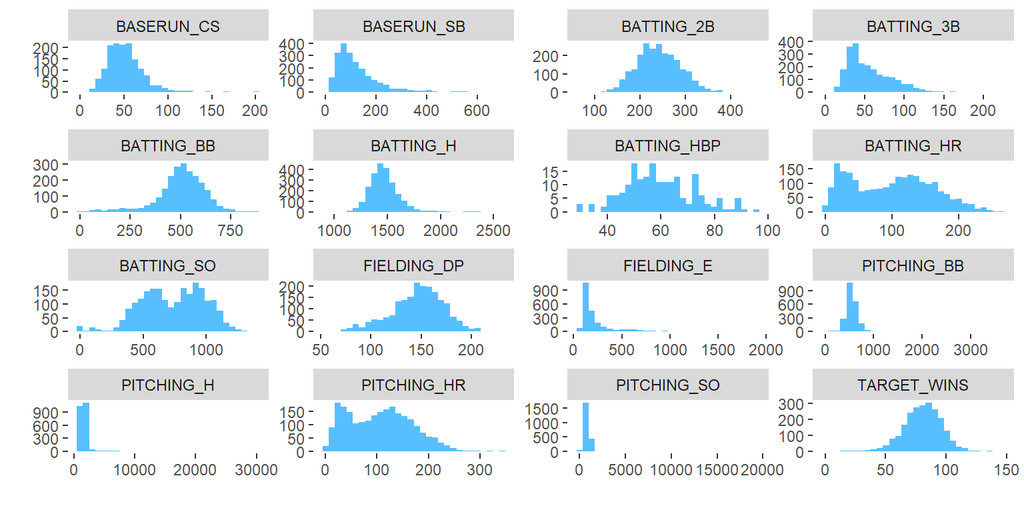

Data Distributions

## 1.3 Outliers

There are also a large number of outliers that need to be accounted for, most prevalently in `FIELDING_E` and `BATTING_H` based off of the boxplots below. One such extreme outlier removed implied that there were, on average per game in a single season, 186 hits allowed by pitchers. This is an unrealistic figure, even for those for whom baseball is outside of their realm of understanding.

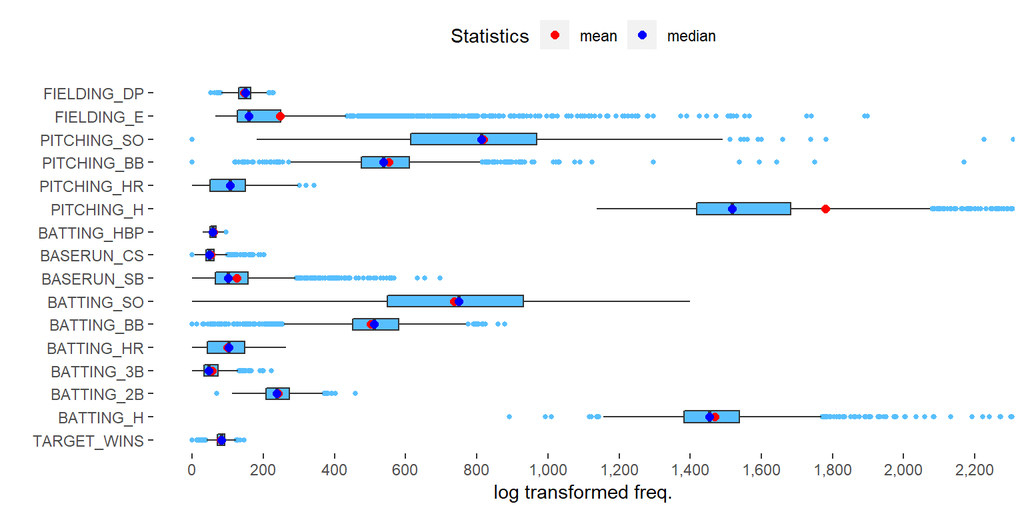

Boxplots highlighting many outliers in the data.

## 1.4 Missing Values

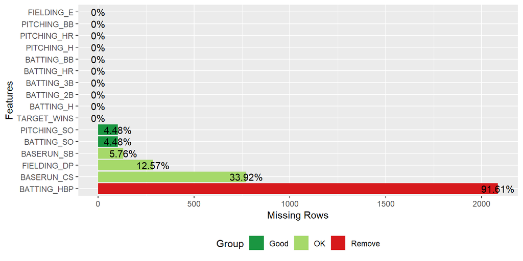

Missing values

## 1.5 Linearity

Each variable was plotted against the target variable in order to determine at a glance which had the most potential linearity before the dataset was modified.

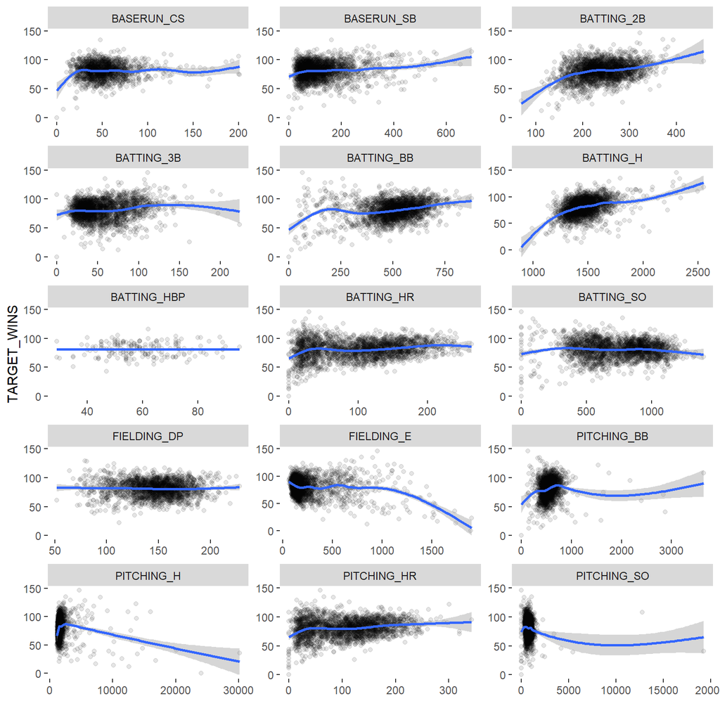

Linear relationships between each predictors and the target

As can be observed, the most influential variables are the ones previously discussed to have severe outliers and skew, and their linear relationship is negative - the higher the variable, the lower the target wins. On the other hand, `BATTING_H`, `BATTING_BB` and `BATTING_2B` showed the most promise.

# 2 DATA PREPARATION

## 2.1 Missing Values

As previously mentioned, just north of 10% of the data was missing values. Missing values can lead to errors in a model, bias, and worse if left unaccounted for. Attempting to “fix” this by imputing values or guessing why the values are missing in the first place - such as concluding that the missing values are meant to be zeroes - are just as likely to help with creating a model as it is to help with creating a disaster.

One of the R packages utilized, DataExplorer, which was used for the chart in the “DATA EXPLORATION” section above, recommends removing null or missing values above a certain threshold as indicated in the graph.

Fixing missing values with imputation may help, but can also have a negative impact on the model if the assumed values do not correspond to the actual missing values. When it is just a few observations missing, modifications can be made, however, 91.61% is too large a proportion and would almost definitely distort the model, so we decided it was better to remove the `BATTING_HBP` column altogether. Deleting all cases with missing values, in this instance, would have shrunk the size of the dataset down to less than a tenth of its original size. If we simply delete all cases with missing values from the analysis, we will cause no bias, but we would most certainly lose a lot of important information.

Data that is Missing Completely at Random (MCAR), meaning the probability that a value is missing is the same for all cases can be imputed. Although there is some concern about whether or not `Pitching_SO` and `Batting_SO` are MCAR, we chose to leave all the remaining variables except `BATTING_HBP` and determine whether or not to remove themn during the modelling process.

### 2.1.1 NA Imputation

To deal with the remaining missing values, the bag imputation method was used via the caret package. A set of dummy variables were created and were used to predict the various values in the dataset. This dummy-set was then pre-processed and used against itself to predict the missing values.

```
##                n  min    mean median   max      sd
## TARGET_WINS 2276    0   80.79   82.0   146   15.75
## BATTING_H   2276  891 1469.27 1454.0  2554  144.59
## BATTING_2B  2276   69  241.25  238.0   458   46.80
## BATTING_3B  2276    0   55.25   47.0   223   27.94
## BATTING_HR  2276    0   99.61  102.0   264   60.55
## BATTING_BB  2276    0  501.56  512.0   878  122.67
## BATTING_SO  2174    0  735.61  750.0  1399  248.53
## BASERUN_SB  2145    0  124.76  101.0   697   87.79
## BASERUN_CS  1504    0   52.80   49.0   201   22.96
## PITCHING_H  2276 1137 1779.21 1518.0 30132 1406.84
## PITCHING_HR 2276    0  105.70  107.0   343   61.30
## PITCHING_BB 2276    0  553.01  536.5  3645  166.36
## PITCHING_SO 2174    0  817.73  813.5 19278  553.09
## FIELDING_E  2276   65  246.48  159.0  1898  227.77
## FIELDING_DP 1990   52  146.39  149.0   228   26.23
```

```
##                n  min    mean  median   max      sd
## TARGET_WINS 2276    0   80.79   82.00   146   15.75
## BATTING_H   2276  891 1469.27 1454.00  2554  144.59
## BATTING_2B  2276   69  241.25  238.00   458   46.80
## BATTING_3B  2276    0   55.25   47.00   223   27.94
## BATTING_HR  2276    0   99.61  102.00   264   60.55
## BATTING_BB  2276    0  501.56  512.00   878  122.67
## BATTING_SO  2276    0  728.23  739.00  1399  246.65
## BASERUN_SB  2276    0  124.63  105.00   697   85.28
## BASERUN_CS  2276    0   70.73   56.43   201   38.01
## PITCHING_H  2276 1137 1779.21 1518.00 30132 1406.84
## PITCHING_HR 2276    0  105.70  107.00   343   61.30
## PITCHING_BB 2276    0  553.01  536.50  3645  166.36
## PITCHING_SO 2276    0  807.63  803.50 19278  543.08
## FIELDING_E  2276   65  246.48  159.00  1898  227.77
## FIELDING_DP 2276   52  145.31  146.00   228   24.90
```

```
##                n min        mean    median max         sd
## TARGET_WINS    0   0   0.0000000  0.000000   0   0.000000
## BATTING_H      0   0   0.0000000  0.000000   0   0.000000
## BATTING_2B     0   0   0.0000000  0.000000   0   0.000000
## BATTING_3B     0   0   0.0000000  0.000000   0   0.000000
## BATTING_HR     0   0   0.0000000  0.000000   0   0.000000
## BATTING_BB     0   0   0.0000000  0.000000   0   0.000000
## BATTING_SO  -102   0   7.3754714 11.000000   0   1.876015
## BASERUN_SB  -131   0   0.1347715 -4.000000   0   2.507556
## BASERUN_CS  -772   0 -17.9280286 -7.427742   0 -15.053684
## PITCHING_H     0   0   0.0000000  0.000000   0   0.000000
## PITCHING_HR    0   0   0.0000000  0.000000   0   0.000000
## PITCHING_BB    0   0   0.0000000  0.000000   0   0.000000
## PITCHING_SO -102   0  10.1004968 10.000000   0  10.004072
## FIELDING_E     0   0   0.0000000  0.000000   0   0.000000
## FIELDING_DP -286   0   1.0780691  3.000000   0   1.327290
```

## 2.2 Remove Outliers

Outlier treament was done by placing a threshold of five times the standard deviation up from the mean and removing all observations that fell north of this boundary.

## 2.3 Correlation

The theoretical effect of strikeouts by batters, batters caught stealing, errors, walks, hits, and homeruns allowed were believed to have a negative impact on the number of wins of an individual team in a given year. A closer look at the correlation plot between the variables painted a different picture.

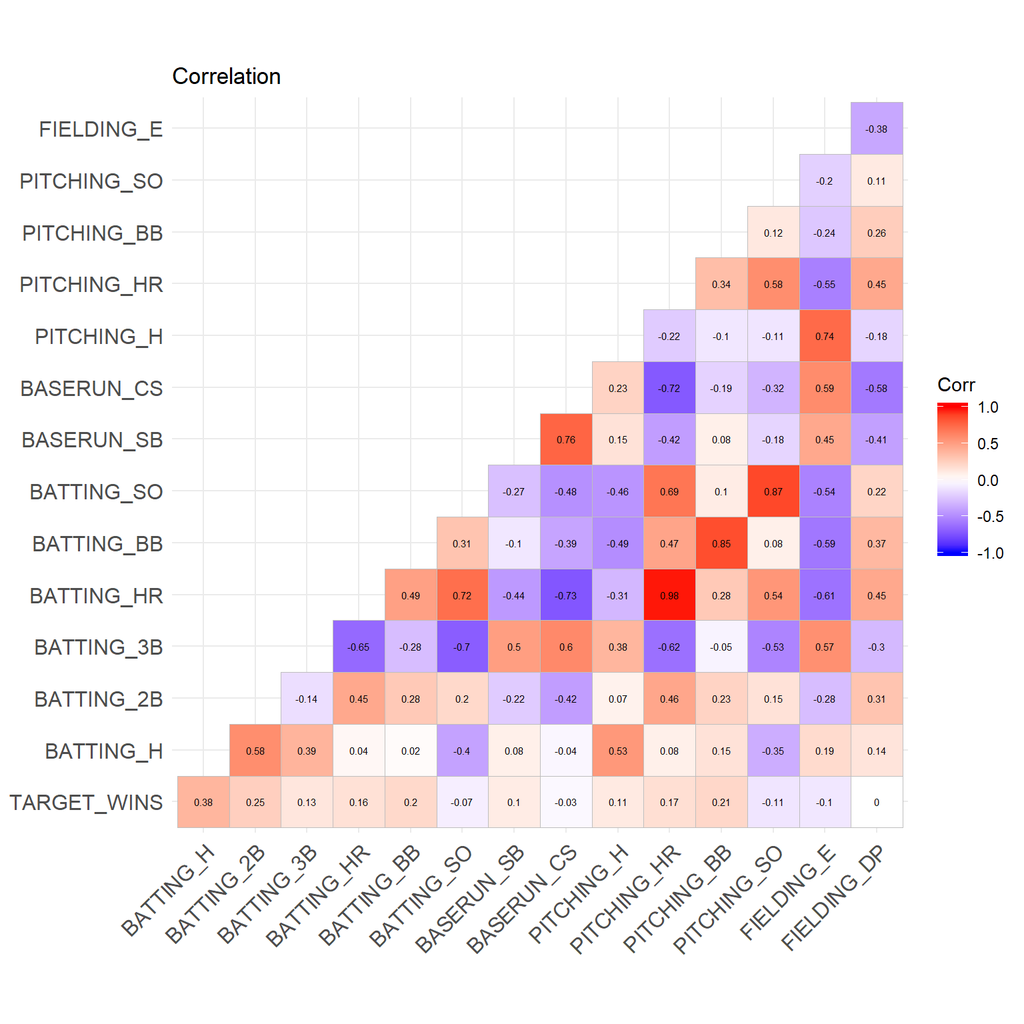

## 2.4 Feature Engineering

Since there are four pairs of related variables that are two sides of the same coin, hits allowed vs. hits by batters, home runs allowed vs. home runs hit by batters, etc. and three of those pairs are highly correlated with each other we decided to try using the difference between them in place of the original variables in our original models. We decided to use offense (batting) minus defense (pitching). These arithmetically transformed offense / defense variables are linearly related with BATTING and PITCHING variables, so we can include one or the other in a model, but not both. However, replacing original variables with these transforms did not improve $R^2$ in a base case.

# 3 BUILD MODELS

## 3.1 MODEL 1

Multiple regression can be created as a purely statistical model, through the use of significance tests, or it can be interpreted in a more practical, non-statistical manner. This approach is based on the subject-area expertise.

We’ve created the following categories from the most important to the least important variables according to the subject-area expert.

Very Important: BATTING_H, BATTING_HR, BATTING_SO ,FIELDING_E, PITCHING_SO

Fairly Important: BASERUN_SB, PITCHING_HR, BATTING_BB

Important: BATTING_2B, BATTING_3B, FIELDING_DP, PITCHING_H

Slightly Important: PITCHING_BB, BASERUN_CS

Not at all important: BATTING_HBP

‘Batters hit by pitch’ and ‘Caught Stealing’ have been eliminated as least important variables according to the expert.

```
##                Estimate  Std. Error     t value     Pr(>|t|)
## (Intercept) 36.59227159 5.663909946   6.4606026 1.278033e-10
## BATTING_H    0.01671944 0.005010218   3.3370691 8.606568e-04
## BATTING_HR   0.11918837 0.050659451   2.3527372 1.872280e-02
## BATTING_SO  -0.03113200 0.006598043  -4.7183691 2.525602e-06
## FIELDING_E  -0.03825885 0.003433165 -11.1439017 4.217234e-28
## PITCHING_SO  0.01996576 0.005419600   3.6839907 2.351124e-04
## BASERUN_SB   0.04144574 0.004934311   8.3994987 7.892888e-17
## PITCHING_HR -0.03498473 0.046875875  -0.7463269 4.555491e-01
## BATTING_BB   0.07833501 0.016216903   4.8304544 1.455372e-06
## BATTING_2B  -0.01106340 0.009389944  -1.1782184 2.388360e-01
## BATTING_3B   0.12637488 0.018154682   6.9610075 4.433682e-12
## FIELDING_DP -0.09122601 0.013110874  -6.9580422 4.525948e-12
## PITCHING_BB -0.05570586 0.014380420  -3.8737299 1.102908e-04
## PITCHING_H   0.01351302 0.001539308   8.7786357 3.239678e-18
```

We got 0.2793 on Adjusted $R^2$ after we removed these two variables. Once we tried to remove other not very important variables according to subject-area expert, we got an even lower $R^2$.

The next step we performed was backward elimunation, which was more effective compared to forward selection. BATTING_H and BATTING_2B have been removed based on the Backward Selection results.

This resulted in the following model:

[output not shown]

```
##                Estimate  Std. Error    t value     Pr(>|t|)
## (Intercept) 50.96736132 3.815684658  13.357331 3.364909e-39
## BATTING_HR   0.13760271 0.050477986   2.725995 6.461210e-03
## BATTING_SO  -0.03318749 0.006582269  -5.041952 4.981386e-07
## FIELDING_E  -0.04164883 0.003244928 -12.835056 1.995570e-36
## PITCHING_SO  0.01869232 0.005383932   3.471871 5.267378e-04
## BASERUN_SB   0.04579083 0.004785457   9.568747 2.769643e-21
## PITCHING_HR -0.03887339 0.046964074  -0.827726 4.079147e-01
## BATTING_BB   0.08589278 0.016054744   5.349994 9.700147e-08
## BATTING_3B   0.15643670 0.016039022   9.753506 4.905956e-22
## FIELDING_DP -0.08357315 0.012949636  -6.453707 1.336225e-10
## PITCHING_BB -0.06196034 0.014270400  -4.341878 1.476224e-05
## PITCHING_H   0.01693109 0.001185182  14.285646 2.346317e-44
```

Our $R^2$ was still low (0.276), so we decided to look at the outliers, which can affect our model. Pitching_h had the high number of outliers which indicated a need for data transformation. We decided to use log transformation for this variable.

```
##                      Estimate   Std. Error     t value     Pr(>|t|)
## (Intercept)     -3.037377e+02 24.255675075 -12.5223350 8.231471e-35
## BATTING_HR       1.134496e-01  0.050029004   2.2676756 2.344480e-02
## BATTING_SO      -1.543857e-02  0.006667500  -2.3154965 2.067660e-02
## FIELDING_E      -4.201715e-02  0.003159393 -13.2991224 6.928751e-39
## PITCHING_SO      7.688177e-03  0.005335672   1.4409015 1.497537e-01
## BASERUN_SB       4.138238e-02  0.004680349   8.8417288 1.879618e-18
## PITCHING_HR     -4.352267e-02  0.046400753  -0.9379734 3.483602e-01
## BATTING_BB       1.011232e-01  0.016002125   6.3193606 3.164812e-10
## BATTING_3B       1.171124e-01  0.015935480   7.3491582 2.789677e-13
## FIELDING_DP     -9.429889e-02  0.012828663  -7.3506406 2.759637e-13
## PITCHING_BB     -7.559524e-02  0.014233269  -5.3111651 1.198021e-07
## log(PITCHING_H)  5.221724e+01  3.243446517  16.0993076 3.078483e-55
```

After we used the log trasformation our model’s Adjusted $R^2$ increased to 0.2921.

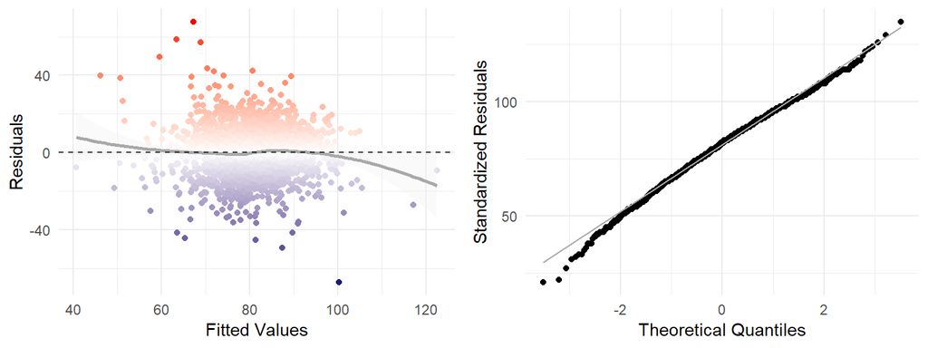

Model 1: Residual Plot and Q-Q Plot

```
##    Min. 1st Qu.  Median    Mean 3rd Qu.    Max.    NA's
##   60.82   76.09   81.12   81.44   86.10  108.26      54
```

```
## # A tibble: 1 x 7
##   r.squared adj.r.squared statistic   p.value    df deviance df.residual
##       <dbl>         <dbl>     <dbl>     <dbl> <int>    <dbl>       <int>
## 1     0.296         0.292      84.6 7.33e-160    12  347583.        2218
```

Summary of Results for Model 1:

The overall Subject-Area expertise wasn’t as effective as a stand alone method of creating multiple regression models. Statistical iterations which were performed contradicted the subject area expert, such as, removing Batting_H from the model. Additionally log tranformation of PITCHING_H made a significant improvment in our model linearity.

## 3.2 MODEL 2

Our approach for Model 2 was to try to use as many of the tools as possible that are available in R and that we have learned thus far to determine a model based solely on the statistical qualities of the predictor variables without any regard to our expert’s opinion.

We started by plotting the relationships between variables that had high correlation values to look for potential collinearity problems.

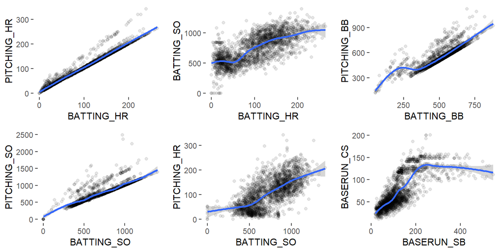

Scatterplots showing possible collinearity problems

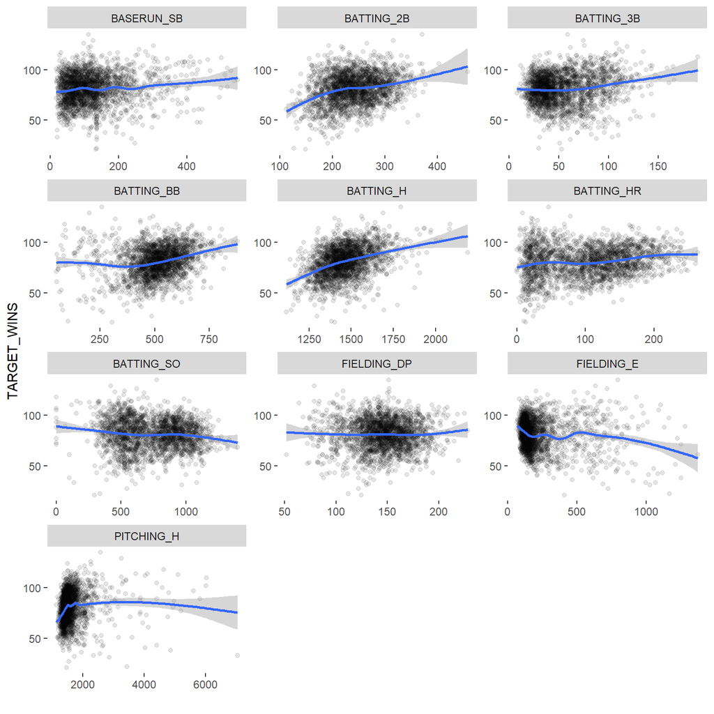

Linear relationship between each predictor and the arget

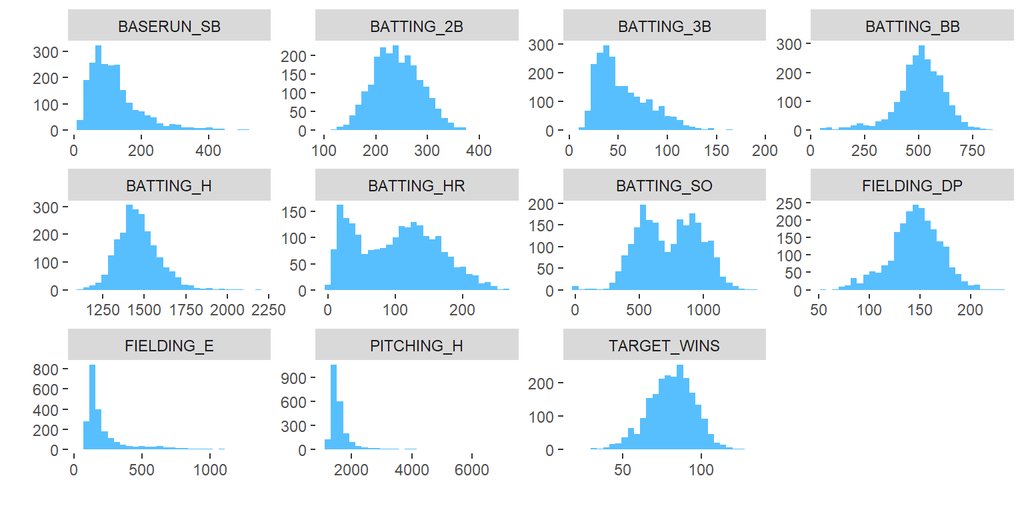

Predictor variable distributions

### 3.2.1 Log Transform Data

We decided to log transform `PITCHING_H`, `FIELDING_E`, `BASERUN_SB` and `BATTING_3B` in order to compensate for the skew. The resulting distributions can be seen in the revised plots below.

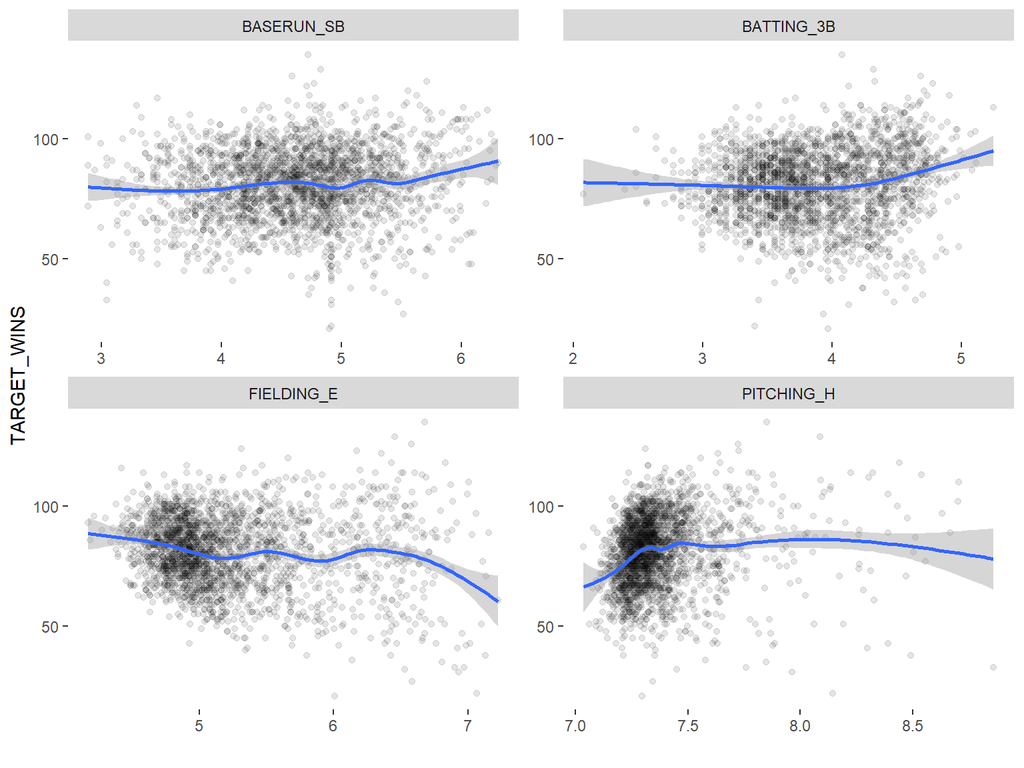

Linear relationship between each log transformed predictor and the Target showing decreased skew

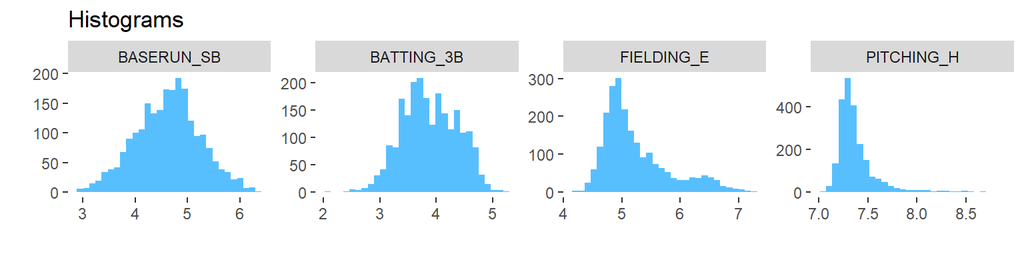

Log transformed distributions showing decreased skew

### 3.2.2 Building the Model

Finally we built a model based on the selected variables including the log transformations where appropriate.

```
TARGET_WINS ~ BATTING_H + BATTING_2B + log(BATTING_3B) + BATTING_HR +
    BATTING_BB + BATTING_SO + log(BASERUN_SB) + log(PITCHING_H) +
    log(FIELDING_E) + FIELDING_DP
```

All of the variables had a very low p-value indicating a significant impact on our target, however our $R^2$ value was low at only 0.2889.

#### 3.2.2.1 $R^2$ 0.2888829

Full Model Coefficients

|  | Estimate | Std. Error | t value | Pr(>\|t\|) |
| --- | --- | --- | --- | --- |
| (Intercept) | -62.9724524 | 15.9139042 | -3.957071 | 0.0000783 |
| BATTING_H | 0.0255615 | 0.0046111 | 5.543426 | 0.0000000 |
| BATTING_2B | -0.0297598 | 0.0092155 | -3.229309 | 0.0012590 |
| log(BATTING_3B) | 6.9697812 | 0.9476551 | 7.354765 | 0.0000000 |
| BATTING_HR | 0.0703282 | 0.0101256 | 6.945579 | 0.0000000 |
| BATTING_BB | 0.0192290 | 0.0031872 | 6.033192 | 0.0000000 |
| BATTING_SO | -0.0112281 | 0.0024113 | -4.656450 | 0.0000034 |
| log(BASERUN_SB) | 4.5460080 | 0.5617657 | 8.092356 | 0.0000000 |
| log(PITCHING_H) | 19.1408576 | 2.6161541 | 7.316411 | 0.0000000 |
| log(FIELDING_E) | -13.1027616 | 1.0618606 | -12.339437 | 0.0000000 |
| FIELDING_DP | -0.1067225 | 0.0131384 | -8.122924 | 0.0000000 |

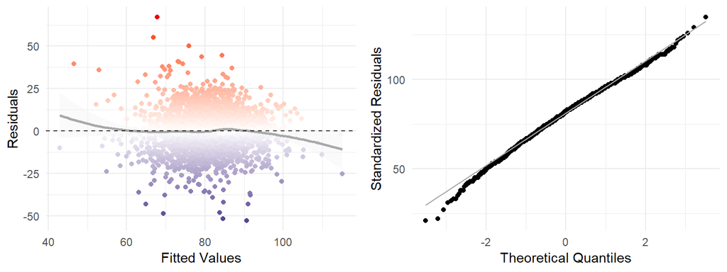

Model 2: Residual Plot and Q-Q Plot

Our residuals look normally distributed and random, and with constant variability, no indication of homoscedasticity. However we thought we may be able to use some other tools in R to refine our model and get a better $R^2$ value. So next we tried using the leaps package to see if it would recommend removing any of our chosen variables from the model. In the following plot you can see that we could remove `BATTING_H`, `BATTING_2B` without affecting out $R^2$ much, but it would not improve the model.

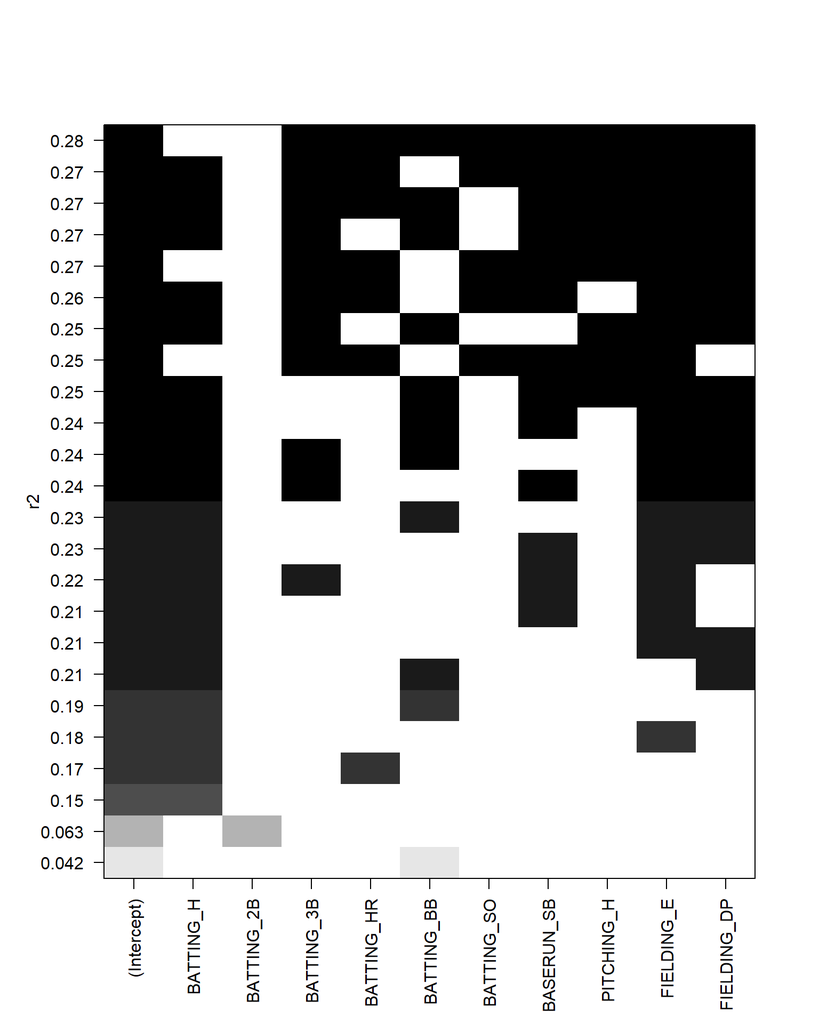

Next we tried standardizing the (non-log-transformed) variables to see what impact that might have on our model. As you can see standardzing actually resulted in a significant reduction in our $R^2$ value from 0.2889 to 0.274.

#### 3.2.2.2 $R^2$ 0.2739688

Full SCALED Model Coefficients

|  | Estimate | Std. Error | t value | Pr(>\|t\|) |
| --- | --- | --- | --- | --- |
| (Intercept) | 80.9717489 | 0.2690639 | 300.938712 | 0.0000000 |
| BATTING_H | 2.6935751 | 0.5977789 | 4.505972 | 0.0000070 |
| BATTING_2B | -0.4725422 | 0.4272176 | -1.106092 | 0.2688064 |
| BATTING_3B | 3.0938480 | 0.4776884 | 6.476708 | 0.0000000 |
| BATTING_HR | 4.8934200 | 0.5902167 | 8.290887 | 0.0000000 |
| BATTING_BB | 1.7865264 | 0.3813959 | 4.684178 | 0.0000030 |
| BATTING_SO | -1.9686032 | 0.5564927 | -3.537519 | 0.0004122 |
| BASERUN_SB | 2.6367694 | 0.3743523 | 7.043551 | 0.0000000 |
| PITCHING_H | 4.5352452 | 0.5648773 | 8.028726 | 0.0000000 |
| FIELDING_E | -6.4017884 | 0.5957772 | -10.745273 | 0.0000000 |
| FIELDING_DP | -2.3837076 | 0.3295935 | -7.232265 | 0.0000000 |

### 3.2.3 Test all of the predictors

Next we ran an ANOVA test to compare our model to the null model. With a p-value that is basically zero, clearly our model is statistically significant.

```
## Analysis of Variance Table
##
## Model 1: TARGET_WINS ~ 1
## Model 2: TARGET_WINS ~ BATTING_H + BATTING_2B + log(BATTING_3B) + BATTING_HR +
##     BATTING_BB + BATTING_SO + log(BASERUN_SB) + log(PITCHING_H) +
##     log(FIELDING_E) + FIELDING_DP
##   Res.Df    RSS Df Sum of Sq      F    Pr(>F)
## 1   2229 493421
## 2   2219 350880 10    142541 90.144 < 2.2e-16 ***
## ---
## Signif. codes:  0 '***' 0.001 '**' 0.01 '*' 0.05 '.' 0.1 ' ' 1
```

### 3.2.4 Testing a subspace

We then tried testing a subspace. Since our initial models using the difference between the corresponding batting and pitching variables did not show promise we tried adding those two variables instead.

#### 3.2.4.1 $R^2$ 0.286633

Subspace Model Coefficients

|  | Estimate | Std. Error | t value | Pr(>\|t\|) |
| --- | --- | --- | --- | --- |
| (Intercept) | -47.5598798 | 14.1082067 | -3.371079 | 0.0007616 |
| I(BATTING_HR + PITCHING_HR) | 0.0361009 | 0.0049624 | 7.274907 | 0.0000000 |
| I(BATTING_BB + PITCHING_BB) | 0.0077316 | 0.0014542 | 5.316742 | 0.0000001 |
| I(BATTING_SO + PITCHING_SO) | -0.0052127 | 0.0010862 | -4.798948 | 0.0000017 |
| BATTING_H | 0.0273198 | 0.0048717 | 5.607838 | 0.0000000 |
| BATTING_2B | -0.0248999 | 0.0093466 | -2.664069 | 0.0077761 |
| log(BATTING_3B) | 6.4554813 | 0.9412999 | 6.858050 | 0.0000000 |
| log(BASERUN_SB) | 3.0279771 | 0.7904181 | 3.830855 | 0.0001312 |
| BASERUN_CS | 0.0460357 | 0.0177169 | 2.598400 | 0.0094279 |
| log(PITCHING_H) | 17.7088157 | 2.6101829 | 6.784511 | 0.0000000 |
| log(FIELDING_E) | -13.7380684 | 1.0992719 | -12.497426 | 0.0000000 |
| FIELDING_DP | -0.0968425 | 0.0134958 | -7.175776 | 0.0000000 |

Once again our model declined in performance rather than improving.

Last, but not least, we used the stepAIC function from the MASS package to see if it came up with different recommendations for what variabels to keep and which to exclude from our model. We started with all variables putting back the ones we had previously taken out due to collinearity issues and let the algorithm choose which to keep.

The final suggested model was:

```
Final Model:
TARGET_WINS ~ BATTING_H + BATTING_3B + BATTING_HR + BATTING_BB +
    BATTING_SO + BASERUN_SB + BASERUN_CS + PITCHING_H + PITCHING_BB +
    PITCHING_SO + FIELDING_E + FIELDING_DP
```

In comparison to our original model we had the following variables added to our model (`BASERUN_CS`, `PITCHING_BB`, and `PITCHING_SO`) and the following variable removed (`BATTING_2B`).

We tried multiple iterations of that model, without any log transformations, with log transformations, with and without the collinear variables, but whever we removed one of the collinear variables our model would decline in performance, so we decided to try our multiplying the corresponding collinear variables to gether and BINGO! We got and $R^2$ of 0.3247 using the following model:

```
TARGET_WINS ~ BATTING_3B + BATTING_HR + BATTING_BB*PITCHING_BB +
    BATTING_SO*PITCHING_SO + BASERUN_SB + BASERUN_CS + BATTING_H*log(PITCHING_H) +
    log(FIELDING_E) + FIELDING_DP
```

#### 3.2.4.2 $R^2$ 0.3247108

Full Model Coefficients

|  | Estimate | Std. Error | t value | Pr(>\|t\|) |
| --- | --- | --- | --- | --- |
| (Intercept) | 204.6302089 | 103.8266135 | 1.9708840 | 0.0488615 |
| BATTING_3B | 0.1602499 | 0.0178747 | 8.9651836 | 0.0000000 |
| BATTING_HR | 0.0721476 | 0.0102070 | 7.0684573 | 0.0000000 |
| BATTING_BB | 0.0624848 | 0.0199429 | 3.1331835 | 0.0017518 |
| PITCHING_BB | -0.0863035 | 0.0130572 | -6.6096358 | 0.0000000 |
| BATTING_SO | 0.0016687 | 0.0091718 | 0.1819433 | 0.8556439 |
| PITCHING_SO | 0.0285700 | 0.0064784 | 4.4100525 | 0.0000108 |
| BASERUN_SB | 0.0304137 | 0.0059322 | 5.1268671 | 0.0000003 |
| BASERUN_CS | 0.0630545 | 0.0157254 | 4.0097229 | 0.0000628 |
| BATTING_H | -0.2185464 | 0.0544015 | -4.0172845 | 0.0000608 |
| log(PITCHING_H) | -8.4383898 | 14.3385415 | -0.5885110 | 0.5562494 |
| log(FIELDING_E) | -16.4657197 | 1.1044063 | -14.9091144 | 0.0000000 |
| FIELDING_DP | -0.0883833 | 0.0131868 | -6.7024185 | 0.0000000 |
| BATTING_BB:PITCHING_BB | 0.0000469 | 0.0000169 | 2.7798125 | 0.0054850 |
| BATTING_SO:PITCHING_SO | -0.0000271 | 0.0000044 | -6.1888757 | 0.0000000 |
| BATTING_H:log(PITCHING_H) | 0.0303947 | 0.0074285 | 4.0916590 | 0.0000444 |

### 3.2.5 Predictions

We ran predictions on our final model and plotted the distribution next to the distribution from our target in the training data set to compare…

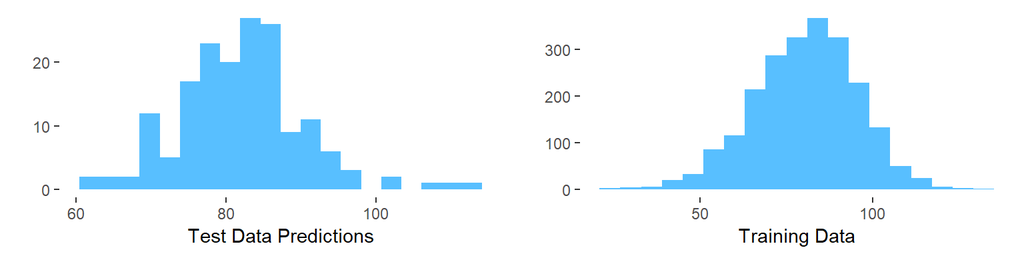

Predictions vs. training data

## 3.3 MODEL 3

We sought to explore whether there was a relationship between wins and the difference of specific offensive and defensive team capabilities - hits, homeruns, balls, and strike-outs. Incorporating variables that reflect those differences (i.e. subtracting batting hits from pitching hits, and so on), however, did not improve the explantory power of the model beyond using the original variables.

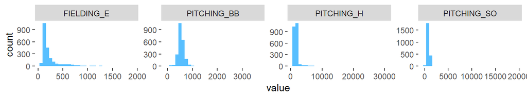

Histograms of variables showing pronounced rightward-skew

Log Transform Model Coefficients

|  | Estimate | Std. Error | t value | Pr(>\|t\|) |
| --- | --- | --- | --- | --- |
| (Intercept) | -405.0139425 | 36.9977658 | -10.946984 | 0.0000000 |
| BATTING_H | -0.0134654 | 0.0060337 | -2.231679 | 0.0257358 |
| BATTING_2B | -0.0150055 | 0.0091463 | -1.640604 | 0.1010214 |
| BATTING_3B | 0.1405383 | 0.0176556 | 7.959979 | 0.0000000 |
| BATTING_HR | 0.0723000 | 0.0097039 | 7.450614 | 0.0000000 |
| BATTING_BB | 0.1246742 | 0.0126620 | 9.846362 | 0.0000000 |
| BATTING_SO | -0.0065541 | 0.0023297 | -2.813291 | 0.0049469 |
| BASERUN_SB | 0.0438045 | 0.0047630 | 9.196774 | 0.0000000 |
| log(PITCHING_H) | 68.6642334 | 5.7601412 | 11.920582 | 0.0000000 |
| PITCHING_BB | -0.0951797 | 0.0106315 | -8.952603 | 0.0000000 |
| FIELDING_E | -0.0473986 | 0.0035504 | -13.350085 | 0.0000000 |
| FIELDING_DP | -0.0885260 | 0.0129387 | -6.841948 | 0.0000000 |

Based on this model’s F-statistic and p-value, we can reject the null hypothesis that coefficients with values of zero would fit the data better. Per the adjusted $r^2$ value, this model explains approximately $29.56\%$ of the variance in wins. However, in doing so it treats the batting hits and batting second base runs as drags on wins (with negative coefficients), and pitching hits as buoying wins - which is counterunituitive. While the other coefficients make more intuitive sense, these signs call into question how effectively we can use this model to understand the relationships between the independent variables and wins.

# 4 SELECT MODELS

## 4.1 Instructions:

Decide on the criteria for selecting the best multiple linear regression model. Will you select a model with slightly worse performance if it makes more sense or is more parsimonious? Discuss why you selected your model. For the multiple linear regression model, will you use a metric such as Adjusted R2, RMSE, etc.? Be sure to explain how you can make inferences from the model, discuss multi-collinearity issues (if any), and discuss other relevant model output. Using the training data set, evaluate the multiple linear regression model based on (a) mean squared error, (b) R2, (c) F-statistic, and (d) residual plots. Make predictions using the evaluation data set.

## 4.2 Comparison of models

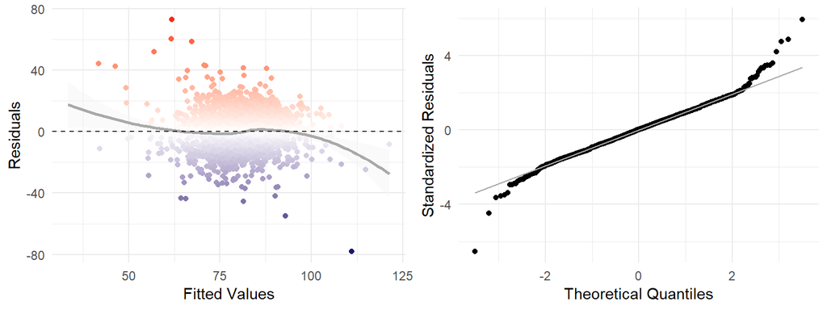

Model 3: Residual Plot and Q-Q Plot

# 5 Appendix